# Project Stage 2

Darshan Patel

2022-08-05

```r
library('moments')
library('dplyr')
library('plyr')
library('pROC')
library('InformationValue')
library('gamlr')
library('glmnet')
library('randomForest')
```

```r
library('rpart')
library('rpart.plot')
library('e1071')
library('party')
```

# 1 Importing Data

```r
data <- read.csv("/Users/darshanpatel/Documents/GitHub/ECO5445SU22/Project 2/hmda_sw.csv", header = TRUE, stringsAsFactors = TRUE)
```

# 2 Data Cleaning with Variable & Co-Variable Identification (A)

The variables in the dataset do not have intuitive names (e.g., the meaning of S3 is unclear). Referencing the data description and the AER paper, identify the qualitative dependent that you will be modeling and the set of covariates that you intend to include in your various models, and rename the variables so that they have (somewhat) intuitive names. Be certain that the debt-to-income ratio and the race, self-employed, marital status, and education indicator variables are included, among other variables.

```r
Variables <- data[ , c("s7", "s46", "s13", "s27a", "s23a", "school", "s31a", "s33", "s40", "s42", "s6", "s48", "netw")]

Names <- c("Result", "Total_DTI", "Race", "Self_Employment", "Marital", "Years_of_Education", "Total_Monthly_Income", "Purchase_Price", "Credit_Check", "Mortgage_Payments", "Loan_Amount", "Loan_Term", "Net_Worth")

colnames(Variables) <- Names

Variables[Variables == 999999.4] <- NA
Variables[Variables == 999999] <- NA

Finalvar <- na.omit(Variables)

Finalvar$Result <- factor(Finalvar$Result, levels = c(1,2,3), labels = c("Approved","Approved","Denied"))
Finalvar$Race <- factor(Finalvar$Race, levels = c(3,5), labels = c("Black", "White"))
Finalvar$Self_Employment <- factor(Finalvar$`Self_Employment`, levels = c(0, 1), labels = c("No", "Yes"))
Finalvar$`Marital` <- factor(Finalvar$Marital, c("M", "U", "S"), labels = c("Married", "Single", "Separate"))
Finalvar$Credit_Check <- factor(Finalvar$`Credit_Check`, levels = c(0,1), c("Fail", "Pass"))
Finalvar$Mortgage_Payments <- factor(Finalvar$Mortgage_Payments, levels = c(1,2,3,4), c ("Not late", "No History", "1-2 Late pmts", "2+ late pmts"))
```

## 2.1 Explanation of Variables

- The qualitative dependent variable I will use is the “Type of action taken” from the “S7” Column.
- The co-variates that I will use in this model include Total debt-to-income ratio, Race, Self-employment, Marital status, Education, Monthly income of the applicant, Purchase Price of House, Credit history meeting loan policy, Credit History for mortgage payments, Loan amount, Term of the loan in months, and Net Worth.
- Data that skewed our results have been removed. In this case, the values of 999999 and 999999.4 were removed
- Moreover, data with integers that represent characteristics (ex: 3 = “Black” under “Race”) have been changed to reflect those characteristics
- Along with the standard DTI, race, self employed, marital status, and education variables stated in the instructions, I decided to also include Purchase Price and Loan amount because the amount an applicant wants to buy a house for affects how much money they would need to borrow from a loan. Moreover, I also chose Net worth, total monthly income, and loan term because I figured that one’s level of monetary stability would indicate more or less risk to loaner in giving them money, which would affect the amount and likelihood of getting approved. Also, the more stable one’s finances are, the more comfortable the bank would allow for a longer loan term. Lastly, I chose Credit check and history for mortgage payments because the applicant’s credit history is always checked before a bank decies to give a loan and usually credit history indicates how likely the bank is going to recover the money they loan out.

# 3 Summary Statistics (B)

Generate summary statistics on the set of variables selected in A, and explain the composition of the sample and of the characteristics of an average (representative) applicant. In the process, you should also generate and histograms and frequency counts on particular variables of interest, which can be referenced in your explanation of the composition of the sample and of a representative applicant.

```r
sum <- summary(Finalvar)
print(sum)
```

```
##       Result       Total_DTI         Race      Self_Employment     Marital
##  Approved:2067   Min.   :  0.00   Black: 335   No :2076        Married :1425
##  Denied  : 281   1st Qu.: 28.18   White:2013   Yes: 272        Single  : 852
##                  Median : 33.00                                Separate:  71
##                  Mean   : 33.12
##                  3rd Qu.: 37.00
##                  Max.   :300.00
##  Years_of_Education Total_Monthly_Income Purchase_Price   Credit_Check
##  Min.   : 5.0       Min.   :    0        Min.   :   0.0   Fail: 205
##  1st Qu.:13.0       1st Qu.: 2692        1st Qu.: 123.0   Pass:2140
##  Median :16.0       Median : 3600        Median : 155.0   NA's:   3
##  Mean   :15.5       Mean   : 4919        Mean   : 190.5
##  3rd Qu.:17.0       3rd Qu.: 5321        3rd Qu.: 215.0
##  Max.   :27.0       Max.   :81000        Max.   :1535.0
##      Mortgage_Payments  Loan_Amount      Loan_Term       Net_Worth
##  Not late     : 738    Min.   :  2.0   Min.   :  6.0   Min.   :-7919.00
##  No History   :1549    1st Qu.: 95.0   1st Qu.:360.0   1st Qu.:   39.00
##  1-2 Late pmts:  40    Median :122.0   Median :360.0   Median :   86.38
##  2+ late pmts :  21    Mean   :139.6   Mean   :342.8   Mean   :  252.89
##                        3rd Qu.:158.0   3rd Qu.:360.0   3rd Qu.:  218.00
##                        Max.   :980.0   Max.   :480.0   Max.   :28023.00
```

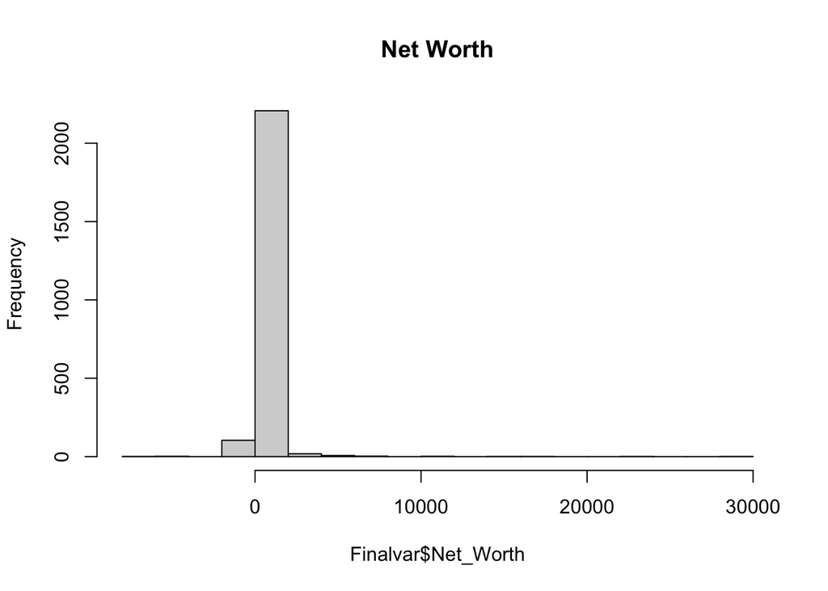

```r
hist(Finalvar$`Net_Worth`, main = "Net Worth")
```

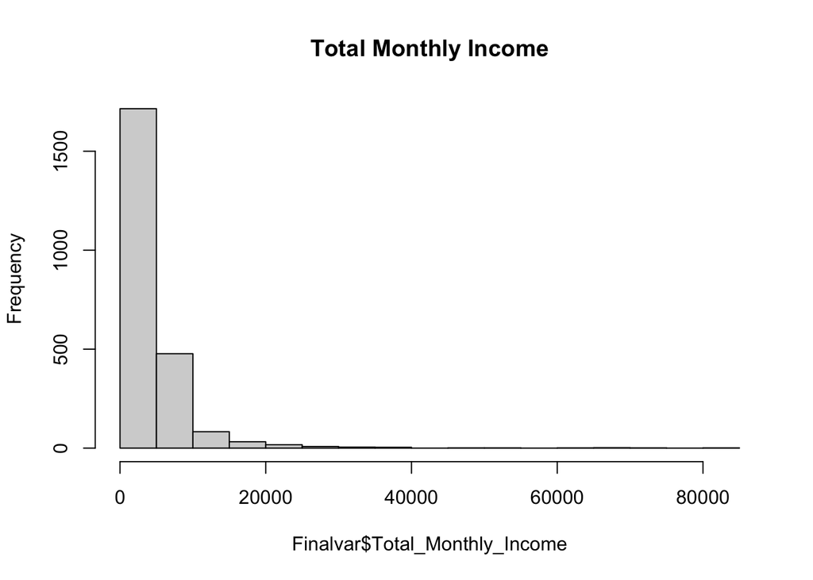

```r
hist(Finalvar$`Total_Monthly_Income`, main = "Total Monthly Income")
```

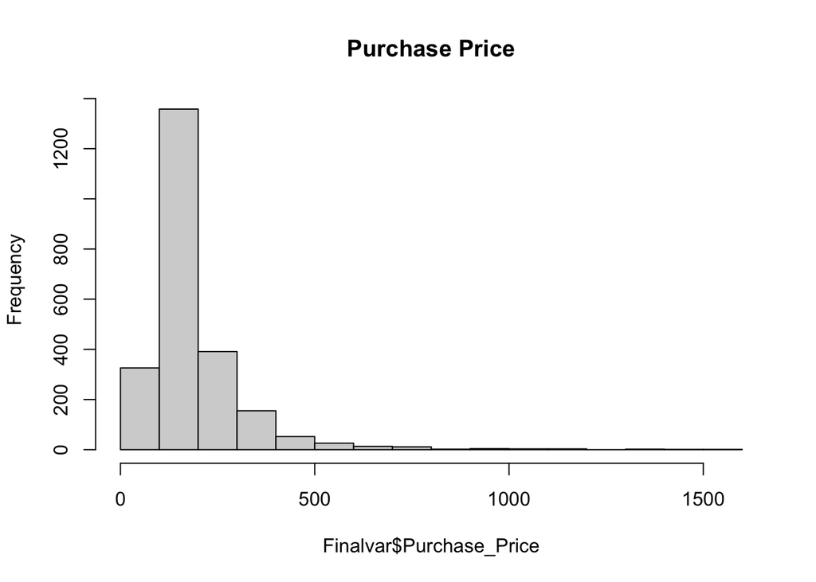

```r
hist(Finalvar$`Purchase_Price`, main = "Purchase Price")
```

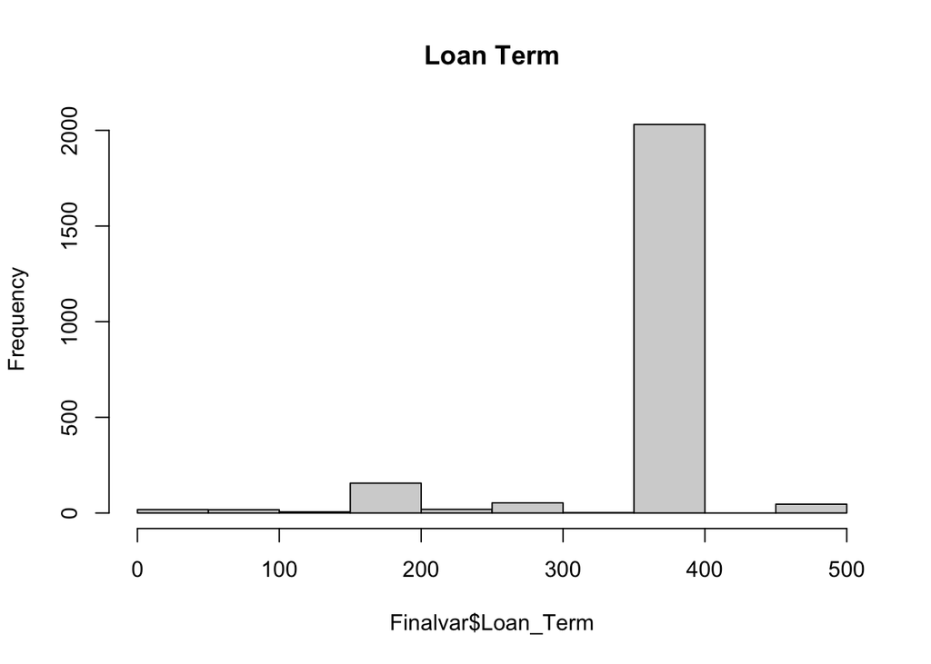

```r
hist(Finalvar$`Loan_Term`, main = "Loan Term")
```

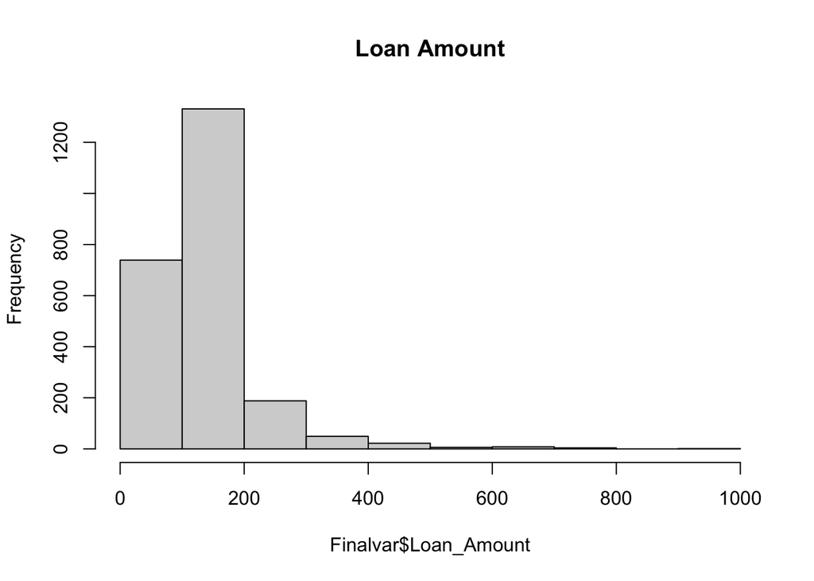

```r
hist(Finalvar$Loan_Amount, main = "Loan Amount")
```

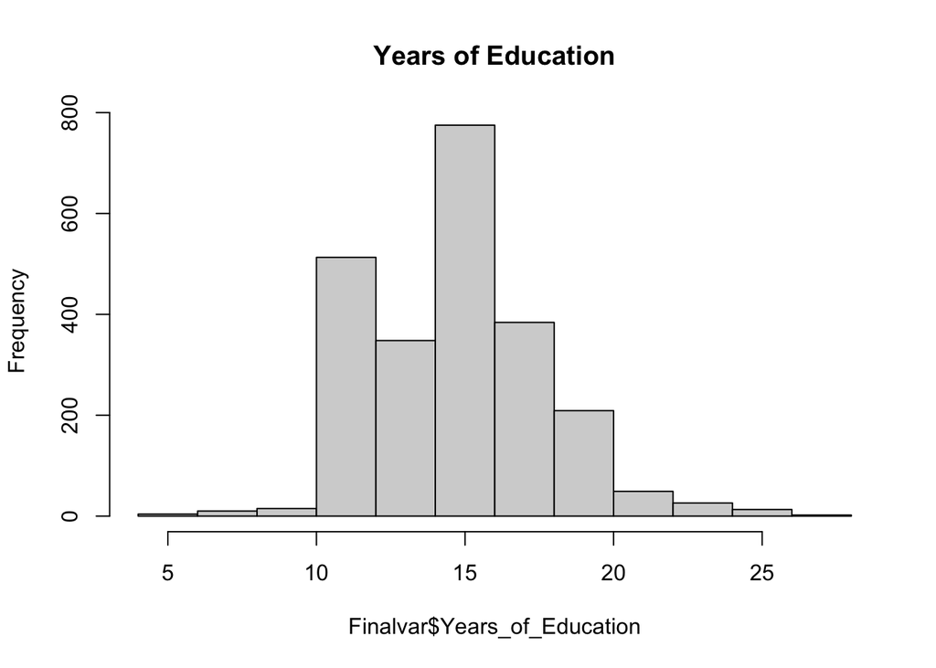

```r
hist(Finalvar$Years_of_Education, main = "Years of Education")
```

```r
sd(Finalvar$`Net_Worth`, na.rm = TRUE)
```

```
## [1] 1074.439
```

```r
sd(Finalvar$`Total_Monthly_Income`, na.rm = TRUE)
```

```
## [1] 5156.424
```

```r
sd(Finalvar$`Purchase_Price`, na.rm = TRUE)
```

```
## [1] 130.8699
```

```r
sd(Finalvar$`Loan_Term`, na.rm = TRUE)
```

```
## [1] 62.8188
```

```r
sd(Finalvar$Loan_Amount, na.rm = TRUE)
```

```
## [1] 83.64259
```

```r
sd(Finalvar$Years_of_Education)
```

```
## [1] 2.875505
```